# STAT435 hw8

## Problem 2

#### (a)

I just use the data from question with the response Y be the queslity of the wine and features x1 be the alcohol of the wine and feature x2 be the pH of the wine.

#### (b)

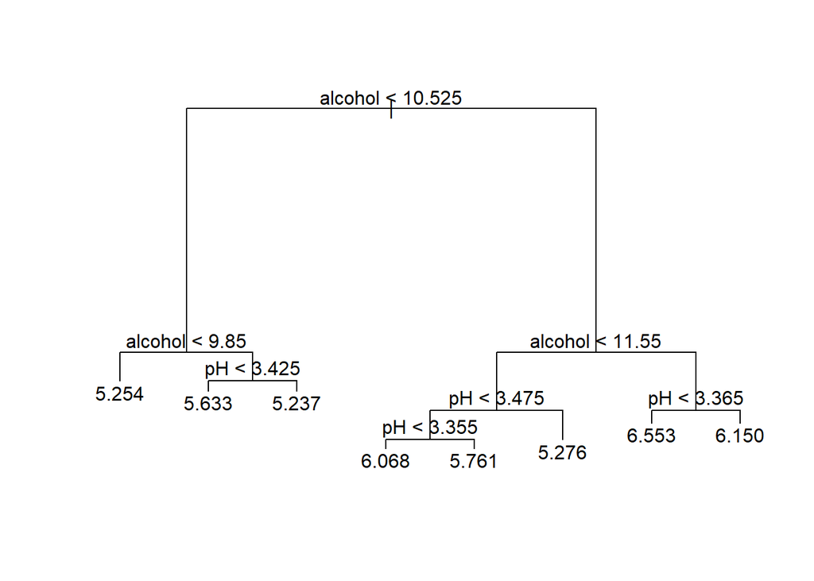

```r
tree.2 = tree(quality ~ alcohol + pH, data = dat, control = tree.control(nobs = 1599, mindev = 0))
prune.3 = prune.tree(tree.2, best = 8)
plot(prune.3)
text(prune.3, pretty = 0)
```

#### (c)

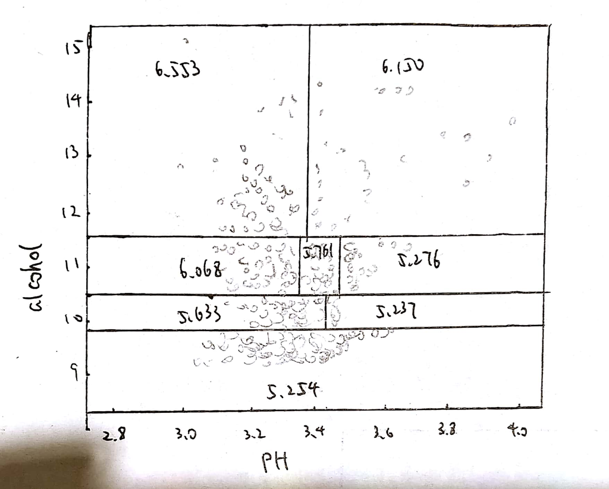

## Problem 3

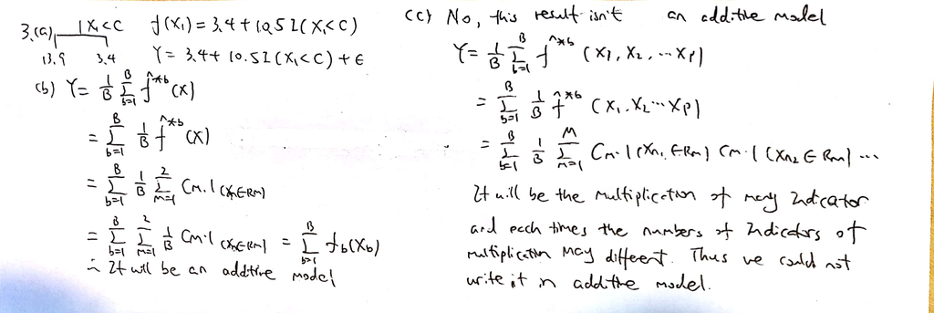

## Problem 4

#### (a)

The variance of the irreducible error is the variance of $\epsilon$, which is 1.

#### (b)

$f(x_1,x_2)=x_1+x_2, Y=x_1+x_2+\epsilon$

Because the relationship between the features and response is approximated linear, which means least square regression will likely work well, and will outperform regression tree that does not exploit this linear structure.

#### (c)

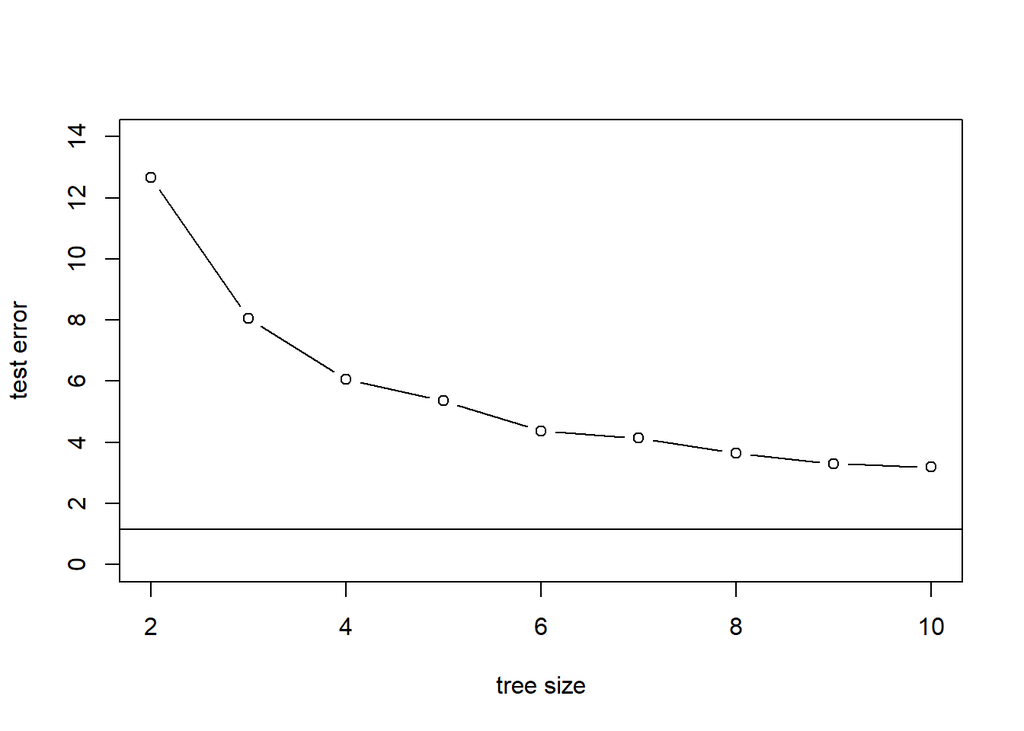

```r
library(tree)
set.seed(1)
x1 = sample((seq(0, 10, len = 1000)))
x2 = sample((seq(0, 10, len = 1000)))
eps = rnorm(1000)
y = x1 + x2 + eps
dat = data.frame(x1, x2, y)
dat1 = dat[1:600, ]
dat2 = dat[601:1000, ]
lm.1 = lm(y ~ x1 + x2, data = dat1)
pred = predict(lm.1, newdata = dat2)
e = mean((dat2$y - pred) ^ 2)
tree.1 = tree(y ~ x1 + x2, data = dat1)
err = numeric(10)
for(i in 2:10) {
  prune = prune.tree(tree.1, best = i)
  pred = predict(prune, newdata = dat2)
  err[i] = mean((dat2$y - pred) ^ 2)
}
plot(2:10, err[2:10], ylim = c(0, 14), type = 'b', xlab = "tree size", ylab = "test error")
abline(h = e)
```

#### (d)

$f(x_1,x_2)=I(x_1<5)+I(x_2<5), Y=I(x_1<5)+I(x_2<5)+\epsilon$

Because the relationship between the features and response are highly non-linear, the least squared regression is not perform well and fit data badly, while regression tree can preform the complex relationship between response and features.

#### (e)

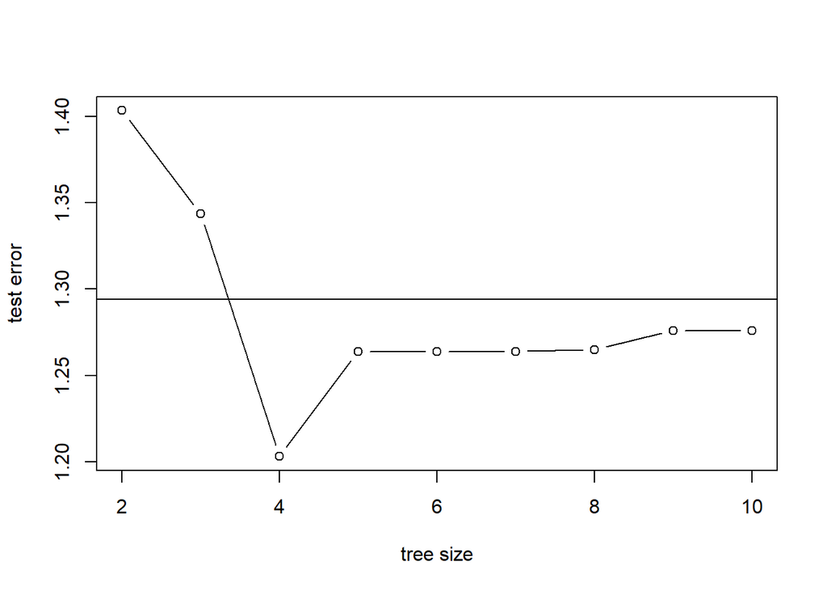

```r
y = I(x1 < 5) + I(x2 < 5) + eps
dat = data.frame(x1, x2, y)
dat1 = dat[1:600, ]
dat2 = dat[601:1000, ]
lm.1 = lm(y ~ x1 + x2, data = dat1)
pred = predict(lm.1, newdata = dat2)
e = mean((dat2$y - pred) ^ 2)
tree.1 = tree(y ~ x1 + x2, data = dat1, control = tree.control(nobs = 600, mindev = 0))
err = numeric(10)
for(i in 2:10) {
  prune = prune.tree(tree.1, best = i)
  pred = predict(prune, newdata = dat2)
  err[i] = mean((dat2$y - pred) ^ 2)
}
plot(2:10, err[2:10], type = 'b', xlab = "tree size", ylab = "test error")
abline(h = e)
```